# STAT 184 Final Project

Zinuo Jia, Alexander Kim

12/17/2019

### Front Matter

```r
# clean up the RStudio environment
rm(list = ls())
# load all packages needed
library(mosaic)
library(DataComputing)
library(tidyverse)
library(lubridate)
library(leaflet)
library(rvest)
library(readr)
library(party)
```

### Project goal

We start with a research question:  
“How does platform that the video games published on influence their sales?” We try to answer this question by analyzing the following two dataset:

Primary dataset: This dataset contains a list of video games with sales greater than 100,000 copies. It was generated by a scrape of vgchartz.com. Fields include  
Rank - Ranking of overall sales  
Name - The games name  
Platform - Platform of the games release (i.e. PC,PS4, etc.)  
Year - Year of the game’s release  
Genre - Genre of the game  
Publisher - Publisher of the game  
NA_Sales - Sales in North America (in millions)  
EU_Sales - Sales in Europe (in millions)  
JP_Sales - Sales in Japan (in millions)  
Other_Sales - Sales in the rest of the world (in millions)  
Global_Sales - Total worldwide sales.

The script to scrape the data is available at https://github.com/GregorUT/vgchartzScrape. It is based on BeautifulSoup using Python. There are 16,598 records. 2 records were dropped due to incomplete information.

```r
#Source data "vgsales.csv" downloaded from "Kaggle.com/dataset"
#vgsales.csv already uploaded in the repo
vgsales <- read_csv("vgsales.csv")
```

```r
#export source data "vgconsole" from "https://en.wikipedia.org/wiki/List_of_best-selling_game_consoles"
page <- "https://en.wikipedia.org/wiki/List_of_best-selling_game_consoles"
tableList <- page %>%
  read_html() %>%
  html_nodes(css = "table") %>%
  html_table(fill = TRUE)
vgconsole<-tableList[[1]]
#write.csv(vgconsole,file = "vgconsole.csv")
#the previous lines is no longer needed once we upload the dataset to git.
#to prevent overwirte orginal data source, we set the last line as a comment.
#By commit and push to git we will have this data set ready next time
```

```r
#Clean the data for a little bit and get a quick look on the dataset
vgconsole<- read.csv("vgconsole.csv")
vgconsole$Ref. <- NULL #took out the Ref. column that has no value
head(vgconsole)
```

|  | Rank | Platform | Firm | Released.2. | Units.sold |
| --- | --- | --- | --- | --- | --- |
| 1 | 1 | PlayStation 2 | Sony | 2000 | >155 million |
| 2 | 2 | Nintendo DS | Nintendo | 2004 | 154.02 million |
| 3 | 3 | Game Boy, Game Boy Color | Nintendo | 1989, 1998 | 118.69 million |
| 4 | 4 | PlayStation 4 | Sony | 2013 | 102.8 million |
| 5 | 5 | PlayStation | Sony | 1994 | 102.49 million |
| 6 | 6 | Wii | Nintendo | 2006 | 101.63 million |

```r
head(vgsales)
```

| Rank | Name | Platform | Year | Genre | Publisher | NA_Sales | EU_Sales | JP_Sales | Other_Sales | Global_Sales |
| --- | --- | --- | --- | --- | --- | --- | --- | --- | --- | --- |
| 1 | Wii Sports | Wii | 2006 | Sports | Nintendo | 41.49 | 29.02 | 3.77 | 8.46 | 82.74 |
| 2 | Super Mario Bros. | NES | 1985 | Platform | Nintendo | 29.08 | 3.58 | 6.81 | 0.77 | 40.24 |
| 3 | Mario Kart Wii | Wii | 2008 | Racing | Nintendo | 15.85 | 12.88 | 3.79 | 3.31 | 35.82 |
| 4 | Wii Sports Resort | Wii | 2009 | Sports | Nintendo | 15.75 | 11.01 | 3.28 | 2.96 | 33.00 |
| 5 | Pokemon Red/Pokemon Blue | GB | 1996 | Role-Playing | Nintendo | 11.27 | 8.89 | 10.22 | 1.00 | 31.37 |
| 6 | Tetris | GB | 1989 | Puzzle | Nintendo | 23.20 | 2.26 | 4.22 | 0.58 | 30.26 |

### Introduction

We can observe our primary data source by using the function `str`

```r
str(vgsales)
```

```
Classes ‘spec_tbl_df’, ‘tbl_df’, ‘tbl’ and 'data.frame':    16598 obs. of  11 variables:
 $ Rank        : num  1 2 3 4 5 6 7 8 9 10 ...
 $ Name        : chr  "Wii Sports" "Super Mario Bros." "Mario Kart Wii" "Wii Sports Resort" ...
 $ Platform    : chr  "Wii" "NES" "Wii" "Wii" ...
 $ Year        : chr  "2006" "1985" "2008" "2009" ...
 $ Genre       : chr  "Sports" "Platform" "Racing" "Sports" ...
 $ Publisher   : chr  "Nintendo" "Nintendo" "Nintendo" "Nintendo" ...
 $ NA_Sales    : num  41.5 29.1 15.8 15.8 11.3 ...
 $ EU_Sales    : num  29.02 3.58 12.88 11.01 8.89 ...
 $ JP_Sales    : num  3.77 6.81 3.79 3.28 10.22 ...
 $ Other_Sales : num  8.46 0.77 3.31 2.96 1 0.58 2.9 2.85 2.26 0.47 ...
 $ Global_Sales: num  82.7 40.2 35.8 33 31.4 ...
 - attr(*, "spec")=
  .. cols(
  ..   Rank = col_double(),
  ..   Name = col_character(),
  ..   Platform = col_character(),
  ..   Year = col_character(),
  ..   Genre = col_character(),
  ..   Publisher = col_character(),
  ..   NA_Sales = col_double(),
  ..   EU_Sales = col_double(),
  ..   JP_Sales = col_double(),
  ..   Other_Sales = col_double(),
  ..   Global_Sales = col_double()
  .. )
```

In this project, we will only analyze the Global sales of each video game.

```r
#Clean up variables that we do not care to keep the data simple. Use vgsales1 as the data set that we will analyze.
vgsales1 <-
  vgsales%>%
  select(Rank,Name,Platform,Year,Genre,Publisher,Global_Sales)
```

##### Clean the Data Source

By checking our data, we can see that we need to clean both data set so we can easily analyze them. Let us first clean the secondary dataset.  
Firstly, we can take a look at the data set.

```r
str(vgconsole)
```

```
'data.frame':   40 obs. of  5 variables:
 $ Rank       : int  1 2 3 4 5 6 7 8 9 10 ...
 $ Platform   : Factor w/ 40 levels "Atari 2600","Atari 5200",..: 22 17 8 24 21 35 23 39 7 25 ...
 $ Firm       : Factor w/ 12 levels "Atari","Bandai",..: 12 8 8 12 12 8 12 6 8 12 ...
 $ Released.2.: Factor w/ 29 levels "1976","1977",..: 19 22 11 27 15 24 24 23 20 22 ...
 $ Units.sold : Factor w/ 36 levels ">1 million",">155 million",..: 2 17 15 14 13 12 6 5 34 33 ...
```

```r
head(vgconsole)
```

|  | Rank | Platform | Firm | Released.2. | Units.sold |
| --- | --- | --- | --- | --- | --- |
| 1 | 1 | PlayStation 2 | Sony | 2000 | >155 million |
| 2 | 2 | Nintendo DS | Nintendo | 2004 | 154.02 million |
| 3 | 3 | Game Boy, Game Boy Color | Nintendo | 1989, 1998 | 118.69 million |
| 4 | 4 | PlayStation 4 | Sony | 2013 | 102.8 million |
| 5 | 5 | PlayStation | Sony | 1994 | 102.49 million |
| 6 | 6 | Wii | Nintendo | 2006 | 101.63 million |

We start to clean the data by rename and change the type of the variables.

```r
names(vgconsole)[c(4,5)] <- c("Released","UnitsSold")
vgconsole<-
  vgconsole%>%
  mutate(Platform = as.character(as.factor(Platform)))%>%
  mutate(Firm = as.character((as.factor(Firm))))
```

From the result, we would like to change the character variable “Unit sold” and “Released” into numerical variable. There are some estimated value like “80–82 million(estimate)” which we will just take its average value, 81 million.

```r
#clean our "million" and other character using regular expression
vgconsole <-
  vgconsole%>%
  mutate(UnitsSold = gsub(pattern = ">", replacement = "", UnitsSold))%>%
  mutate(UnitsSold = gsub(pattern = "\\million|\\(estimate)", replacement = "", UnitsSold))%>%
   mutate(UnitsSold = gsub(pattern = "\\ ", replacement = "", UnitsSold))
```

```r
#change three of the data into their mean values. Note that at this point the variable "UnitsSold" is still in chracteristic.
vgconsole[10,5] = 81
vgconsole[23,5] = 12.5
vgconsole[24,5] = 11.5
#There is one combined data which we will treat them as one case.
vgconsole[3,2:4] = c("Game Boy","Nintendo",1989)
#change variable type
vgconsole <-
  vgconsole%>%
  mutate(Released = readr::parse_number(as.character(Released)))%>%
  mutate(UnitsSold =readr::parse_number(as.character(UnitsSold)))
```

Then we can clean our primary data, since this data set is produced by other people for data analysis already, so we will only need to change the “year” variable into numerical variable.

```r
vgsales1 <-
  vgsales1%>%
  mutate(Year = as.numeric(as.character((Year))))
```

```
NAs introduced by coercion
```

##### Data Wrangling

In order to answer our research question, we try to show the relations between variables by visualization and modling. Before we build our model, we need to transfer all our required variables and put them in one dataset. To do this, we can combine our two data source by a joining function, but note that, in our secondary data source, We use full name of platform which is different from our primary data. We can combine two data source by creating a data frame that matches platform names.

```r
#Create a list of full platform names
PlatformFull <-
  vgconsole%>%
  select(Platform)
PlatformFull
```

| Platform |
| --- |
| PlayStation 2 |
| Nintendo DS |
| Game Boy |
| PlayStation 4 |
| PlayStation |
| Wii |
| PlayStation 3 |
| Xbox 360 |
| Game Boy Advance |
| PlayStation Portable |

[output cut: 30 more lines]

```r
#Create a list of short platform names
PlatformAbb <-
  vgsales%>%
  group_by(Platform)%>%
  summarise(count = n())%>%
  select(Platform)
names(PlatformAbb) <- "PlatformAbb"
PlatformAbb
```

| PlatformAbb |
| --- |
| 2600 |
| 3DO |
| 3DS |
| DC |
| DS |
| GB |
| GBA |
| GC |
| GEN |
| GG |

[output cut: 21 more lines]

```r
Platform2 <-
  PlatformAbb %>%
  mutate(Platform = c("Atari 2600","3D0 Interactive Multiplayer","Nintendo 3DS", "Dreamcast","Nintendo DS", "Game Boy","Game Boy Advance", "GameCube","Sega Genesis", "Sega Game Gear","Nintendo 64", "Nintendo Entertainment System","Neo Geo", "Personal Computer","NEC PC-FX", "PlayStation","PlayStation 2", "PlayStation 3","PlayStation 4", "PlayStation Portable","PlayStation Vita", "Sega Saturn","Nintendo Supplemental Computing Device", "Super Nintendo Enteratainment System","TurboGrafx-16", "Wii","Wii U", "WonderSwan","Xbox 360", "Xbox","Xbox One"))
head(Platform2)
```

| PlatformAbb | Platform |
| --- | --- |
| 2600 | Atari 2600 |
| 3DO | 3D0 Interactive Multiplayer |
| 3DS | Nintendo 3DS |
| DC | Dreamcast |
| DS | Nintendo DS |
| GB | Game Boy |

Now we have a data frame with platform names matched with their abbreviation. We can use two join function to combine two datasets, and again we will select only the variables that we need.

```r
vgconsole <-
vgconsole %>%
  inner_join(Platform2)%>%
  select(PlatformAbb,Released,UnitsSold)
head(vgconsole)
```

|  | PlatformAbb | Released | UnitsSold |
| --- | --- | --- | --- |
| 1 | PS2 | 2000 | 155.00 |
| 2 | DS | 2004 | 154.02 |
| 3 | GB | 1989 | 118.69 |
| 4 | PS4 | 2013 | 102.80 |
| 5 | PS | 1994 | 102.49 |
| 6 | Wii | 2006 | 101.63 |

However, since we are analyzing possible variables that may influence video game sales, here is one more variable which might be a factor. By calculating the mean sales by each platform, we may find it influencial to games total sales.

```r
MeanbyPlatform<-
vgsales1 %>%
  group_by(Platform)%>%
  summarise(MeanSale = mean(Global_Sales))%>%
  arrange(desc(MeanSale))
head(MeanbyPlatform)
```

| Platform | MeanSale |
| --- | --- |
| GB | 2.6066327 |
| NES | 2.5619388 |
| GEN | 1.0503704 |
| SNES | 0.8370293 |
| PS4 | 0.8276786 |
| X360 | 0.7746719 |

Now we have transformed our secondary datas into the form that we need. We now combine this new data with our primary dataset.

```r
vgsales1 <-
vgsales1%>%
  left_join(vgconsole,by=c("Platform" = "PlatformAbb"))%>%
  left_join(MeanbyPlatform)
head(vgsales1)
```

| Rank | Name | Platform | Year | Genre | Publisher | Global_Sales | Released | UnitsSold | MeanSale |
| --- | --- | --- | --- | --- | --- | --- | --- | --- | --- |
| 1 | Wii Sports | Wii | 2006 | Sports | Nintendo | 82.74 | 2006 | 101.63 | 0.6994038 |
| 2 | Super Mario Bros. | NES | 1985 | Platform | Nintendo | 40.24 | 1983 | 61.91 | 2.5619388 |
| 3 | Mario Kart Wii | Wii | 2008 | Racing | Nintendo | 35.82 | 2006 | 101.63 | 0.6994038 |
| 4 | Wii Sports Resort | Wii | 2009 | Sports | Nintendo | 33.00 | 2006 | 101.63 | 0.6994038 |
| 5 | Pokemon Red/Pokemon Blue | GB | 1996 | Role-Playing | Nintendo | 31.37 | 1989 | 118.69 | 2.6066327 |
| 6 | Tetris | GB | 1989 | Puzzle | Nintendo | 30.26 | 1989 | 118.69 | 2.6066327 |

##### Visualization & Modeling

We want to see the basic relationship among the platforms in global sales. This helps build a fundamental idea and question for the rest of the analysis discussed further. This first graph is to see which platform had the greatest sale globally.

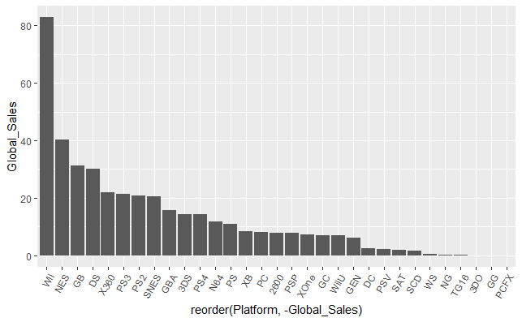

```r
Platforms <- vgsales1 %>%
  group_by(Platform) %>%
  filter(rank(desc(Global_Sales))==1)%>%
  ggplot(aes(x=reorder(Platform,-Global_Sales),y=Global_Sales ))+
  geom_bar(stat='identity',position='stack', width=.9)+
  theme(axis.text.x=element_text(angle=60,hjust=1))
Platforms
```

And see which game had the greatest global sales.

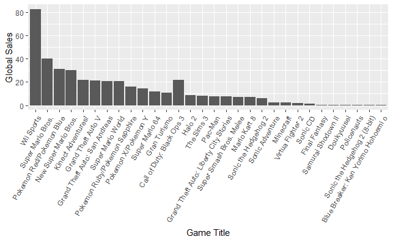

```r
  vgsales1 %>%
  group_by(Platform) %>%
  filter(rank(desc(Global_Sales))==1)%>%
  ggplot(aes(x=reorder(Name,-Global_Sales),y=Global_Sales ))+
  geom_bar(stat='identity',position='stack', width=.9) +
  theme(axis.text.x=element_text(angle=60,hjust=1)) +
  xlab("Game Title") + ylab("Global Sales")
```

Combining the two graphs above, we want to see the global sales over time for each platform that includes all of the released titles. A time series graph of platforms’ global sales in millions is shown below.

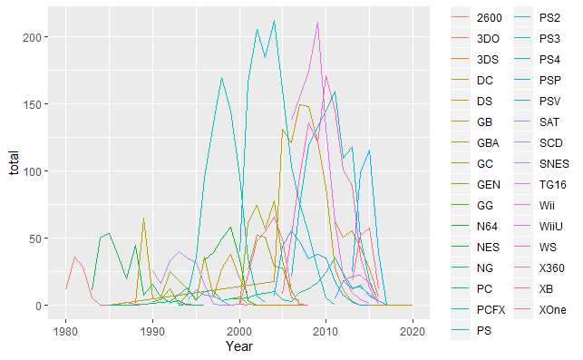

```r
vgsales2 <- vgsales1 %>%
  group_by(Platform, Year) %>%
  summarise(total=sum(Global_Sales))
time <- ggplot() +geom_line(data=vgsales2, aes(x=Year, y=total, col=Platform))
time
```

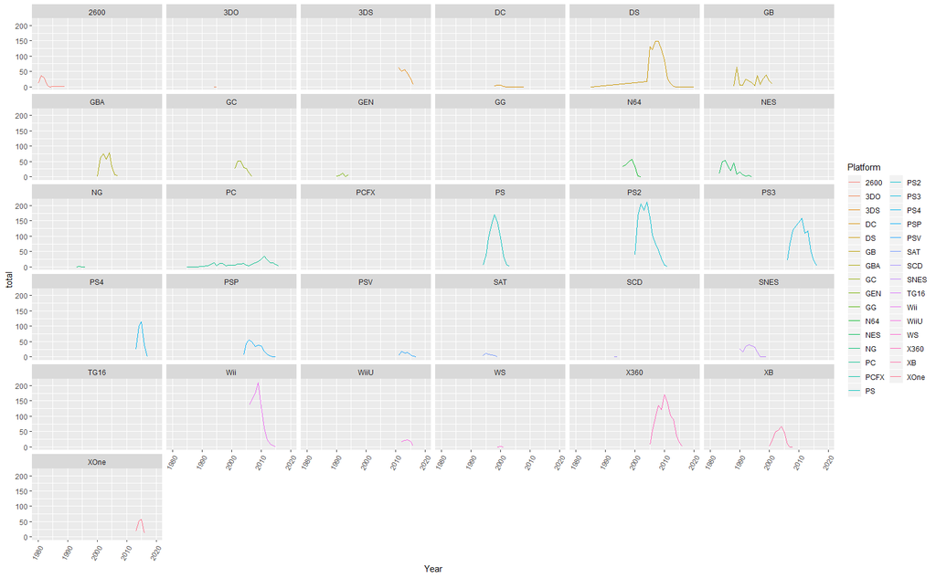

```r
ind_time<- time + facet_wrap(vars(Platform)) +
  theme(axis.text.x=element_text(angle=60,hjust=1))
ind_time
```

Now we have all the variables we need and we can start to build our model using Global sales as a response variable and all other variables as predictor variables. We can address a linear model for all our numerical variables.

```r
attach(vgsales1)
MLR <- lm(Global_Sales~Released+UnitsSold+MeanSale+Year)
detach(vgsales1)
summary(MLR)
```

```
Call:
lm(formula = Global_Sales ~ Released + UnitsSold + MeanSale +
    Year)

Residuals:
   Min     1Q Median     3Q    Max
-2.768 -0.462 -0.262  0.016 81.829

Coefficients:
              Estimate Std. Error t value Pr(>|t|)
(Intercept)  3.7202472  4.8516933   0.767   0.4432
Released     0.0524366  0.0060965   8.601   <2e-16 ***
UnitsSold    0.0006268  0.0002914   2.151   0.0315 *
MeanSale     1.0400906  0.0446510  23.294   <2e-16 ***
Year        -0.0542314  0.0058103  -9.334   <2e-16 ***
---
Signif. codes:  0 ‘***’ 0.001 ‘**’ 0.01 ‘*’ 0.05 ‘.’ 0.1 ‘ ’ 1

Residual standard error: 1.566 on 15118 degrees of freedom
  (1475 observations deleted due to missingness)
Multiple R-squared:  0.04063,   Adjusted R-squared:  0.04038
F-statistic: 160.1 on 4 and 15118 DF,  p-value: < 2.2e-16
```

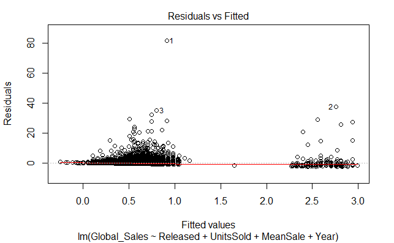

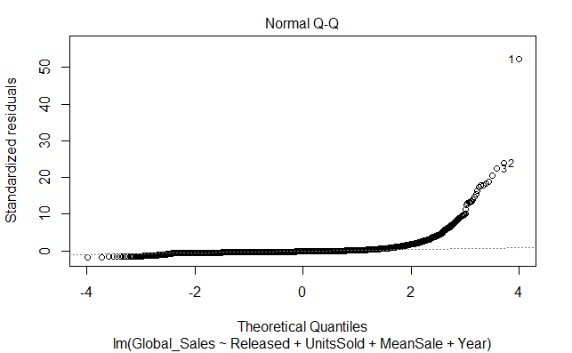

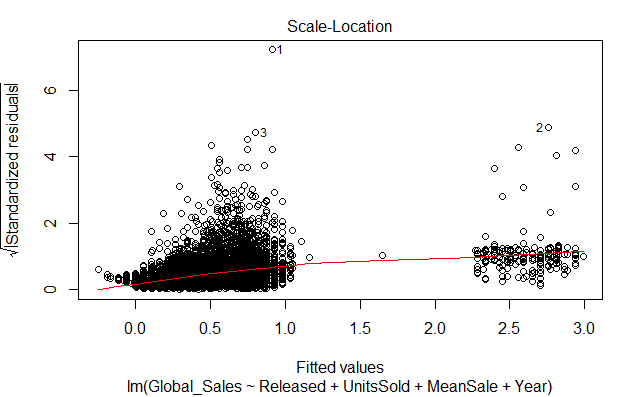

```r
plot(MLR)
```

```
only using the first two of 5 regression coefficients
```

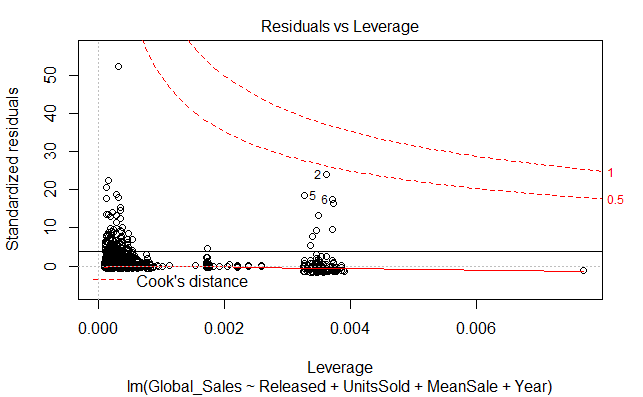

```r
abline(MLR)
```

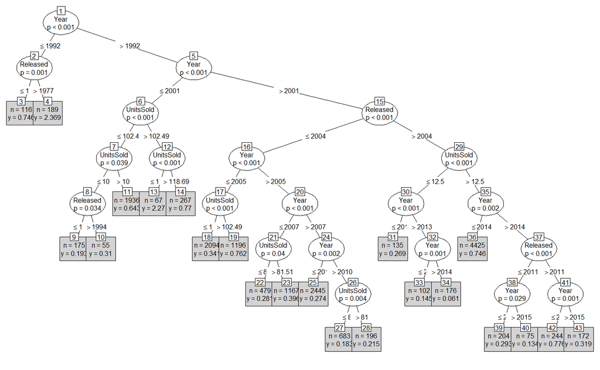

```r
mod1<-party::ctree(Global_Sales~Released+UnitsSold+Year, data=vgsales1)
plot(mod1, type="simple")
```

```r
vgsales%>%
  mutate(probability = as.numeric(predict(mod1)),
         likelihood =
           ifelse(Global_Sales,
                  probability,
                  1-probability)) %>%
  summarise(log_likelihood=sum(log(likelihood)))
```

| log_likelihood |
| --- |
| -12816.75 |

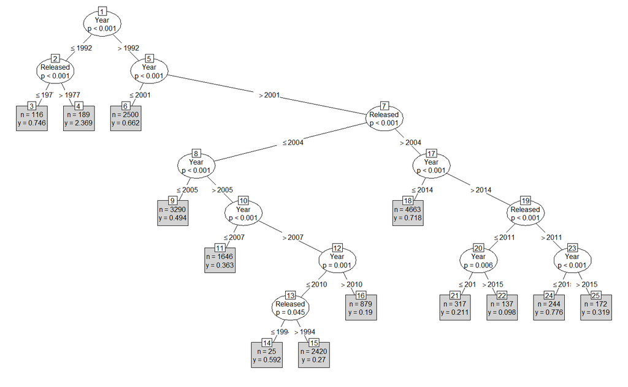

```r
mod2 <- party::ctree(
  Global_Sales~Released+Year, data=vgsales1
)
plot(mod2, type="simple")
```

```r
vgsales%>%
  mutate(probability = as.numeric(predict(mod2)),
         likelihood =
           ifelse(Global_Sales,
                  probability,
                  1-probability)) %>%
  summarise(log_likelihood=sum(log(likelihood)))
```

| log_likelihood |
| --- |
| -12145.28 |

In conclusion, we were able to analyze the platform and game as well as find a regression for our model of Global Sales. Althought the features that affected global sales were found, because of its lack of normality, the model is not the most accuracte. This may be due to the lack of features for analysis that would influence global sales such as the average age of target customers for each genre, game, and platform, or the gender, and the location of country with greatest sales i.e. Microsoft (Xbox) failed in Japan.